# Analyze IMPRINTS or IMPRINTS MS-CETSA datasets in a user friendly way

Marc-Antoine Gerault

2025-05-19

## Introduction

The IMPRINTS.CETSA.app package totally depends on the IMPRINTS.CETSA package, written by Dai Lingyun. If you’re not familiar with this package, go see its [github page](https://github.com/nkdailingyun/IMPRINTS.CETSA) or type ‘browseVignettes(package = “IMPRINTS.CETSA”)’ in the R console if you already installed it. The main goal of IMPRINTS.CETSA .app package is to provide a “user-friendly” interface of the IMPRINTS.CETSA package thanks to a shiny app. The app contains 6 tabs :

1. Analysis
   - Do the whole analysis of your IMPRINTS MS-CETSA datasets on the protein and peptide level
2. Database
   - Save, remove or rename as many datasets as you want in the app
3. Visualization
   - Plot the barplots from your datasets, check for protein complexes and similar IMPRINTS profiles
   - Get heatmap from your datasets according to the category or the protein complex
4. Gene Ontology
   - Get the STRING network and peform enrichment analysis.
   - Get interactive STRING network with barplots inside each node
   - Peform GSEA analysis using clusterProfiler package
5. Cell
   - Print the proteins on an interactive cell according to their cellular location (depends on the Protein Atlas database)
6. PubMed Search
   - Check if other papers have been published on PubMed according to your criterias

In every features of the app, you will be able to use the data from the database but also be able to import your own data. The package contains also other functions that you can use with R commands workflow; we will get through those in this vignette.

## Prerequisites

- R version > 4.0.0
- Rstudio version > 1.0
- Dependent packages:  
  “IMPRINTS.CETSA”, “ggplot2”, “stringr”, “tidyr”, “magick”, “shiny”, “shinydashboard”, “shinycssloaders”, “DT”, “rio”, “purrr”, “dplyr”, “plyr”, “shinyjs”, “cowplot”, “plotly”, “pubmedR”, “rentrez”, “XML”, “gridExtra”, “rjson”, “bibliometrix”, “officer”, “colourpicker”, “openxlsx”, “visNetwork”, “STRINGdb”, “clusterProfiler”, “biomaRt”, “enrichplot”, “multtest”

Some packages are not from CRAN and hence will not be installed when you will install IMPRINTS.CETSA .app package :  
“IMPRINTS.CETSA”, “STRINGdb”, “clusterProfiler”, “biomaRt”, “enrichplot”, “multtest”. For the IMPRINTS.CETSA package, you’ll need the last version from github. For the others, you can install them from BioConductor. For this, type these commands in the R console :

```r
if(!requireNamespace("BiocManager", quietly = TRUE)){ #check if you already have the BiocManager package
 install.packages("BiocManager")  #if not, install it
}
BiocManager::install("STRINGdb")
BiocManager::install("clusterProfiler")
BiocManager::install("biomaRt")
BiocManager::install("enrichplot")
BiocManager::install("multtest")
```

The IMPRINTS.CETSA .app package is currently on github, so for installing it you’ll also need the “devtools” package. You can install the IMPRINTS.CETSA .app package with this commands :

```r
if(!requireNamespace("devtools", quietly = TRUE)){ #check if you already have the devtools package
 install.packages("devtools")  #if not, install it
}
devtools::install_github("mgerault/IMPRINTS.CETSA.app")
```

To install the IMPRINTS.CETSA package (if not already done), you can use the same command :

```r
devtools::install_github("nkdailingyun/IMPRINTS.CETSA")
```

You can access the same informations (and the source code) on the [github repository](https://github.com/mgerault/IMPRINTS.CETSA%20.app)

## Set up

1. For better organization of data analysis, it is **highly recommended** to use the [Project management feature](https://support.rstudio.com/hc/en-us/articles/200526207-Using-Projects) in Rstudio.  
   For each project, you are suggested to create a brand new working folder as your local working directory.  
   When you will use the package and/or the app inside this directory, all your results will be saved in this directory. Indeed, when you will load the package, it will save the path of your working directory under the variable WD. You can modify it if you want to quickly change your saving directory, but only do it if you are sure and of course if your file exists.
2. Call `IMPRINTS.CETSA.app` package

```r
library("IMPRINTS.CETSA.app")
```

## Analysis

### Run the shiny app

```r
runCETSAapp()      #this function will directly start the app
```

If you want more informations on how to use the app, I recommend you to watch the [tutorial](https://youtu.be/cOlOzU7-S3A).

### An overview from the functions

#### $\underline{1.\space The\space data\space}$

The package contains also some data from “Modulation of Protein-Interaction States through the Cell Cycle” from Dai et al. 2018, that you can play with. Let’s take a look at the data called `drug_data`. `drug_data` is a list that contains two datasets : “elutriation” and “chemarrest”.

For each dataset, you will find :

- The caldiff output (the protein abundance fold-change); access it with `$data`
- The imprints_average output (the average from the caldiff output among the bioreplicates); access it with `$data_ave`
- The hitlist; access it with `$hitlist`
- The proteins categorized as “NN”; access it with `$NN`
- The trement level; access it with `$treat_level`

```r
mydata_caldiff <- drug_data$data$elutriation  #save your data
mydata_ave <- drug_data$data_ave$elutriation

View(mydata_caldiff)  #take a look at the data
View(mydata_ave)
```

#### $\underline{2.\space See/save\space the\space barplot}$

The IMPRINTS.CETSA package already contains the imprints_barplotting function; imprints_barplotting_app is totally based on this function. This one allow you to save or not the file; add the category and/or a score on the barplots in the subtitle (to do so, just add a category and/or a score columns named “category” and “score”); use joined dataset; use a named list of dataset (will plot all the barplots from each dataset, usefull when dataset according to the protein complex or cellular location for example). Also, the bar plots will not be generated in an external window; however to keep information on how the function is running, the remaining number of pages to be saved is printed.

```r
imprints_barplotting_app(mydata_caldiff, ret_plot = FALSE, save_pdf = TRUE) #will save all the barplots from the data

mydata_caldiff_chemarrest <- drug_data$data$chemarrest
all_drug <- list("elutriation" = mydata_caldiff, "chemarrest" = mydata_caldiff_chemarrest)
imprints_barplotting_app(all_drug, ret_plot = FALSE, save_pdf = TRUE) #will save all the barplots from the data
#here, it will "join" the two pdf in one
```

Instead of doing a list of all our data, we could also get list of our data according to the protein complex. For this, you’ll need the function imprints_complex_mapping from IMPRINTS.CETSA.

```r
library(IMPRINTS.CETSA)
mydata_hit <- drug_data$hitlist$elutriation
#will map the proteins categorized as CN, CC and NC in S treatment to some protein complex (core Corum database)
map_compl <- imprints_complex_mapping(mydata_ave, mydata_hit, treatment = "S",
                                      targetcategory = c("CN", "CC", "NC"))
View(map_compl) #if you want to check the data

map_compl <- map_compl[, c("ComplexName", "subunitsNum", "subunitsIdentifiedNum",  #keep columns of interest
                                 "id", "description", "gene", "category")]

if(nrow(map_compl) !=0){
  map_compl$description <- unname(unlist(sapply(map_compl$description, IMPRINTS.CETSA .app:::getProteinName))) #keep only protein names in description
}
```

Now that we know some protein complexes, we can build our list.

```r
data_l <- list() #initialize list
some_complex <- unique(map_compl$ComplexName)
some_complex <- some_complex[sample(1:length(some_complex), 4)]
for(i in some_complex){
  cate_ <- map_compl[which(map_compl$ComplexName == i), ]
  pr_comp <- unique(cate_$id)

  data_l[[i]] <- ms_subsetting(mydata_caldiff, isfile = F, hitidlist = c(pr_comp)) #filter the proteins from those complexes

  data_l[[i]]$category <- cate_$category[which(!is.na(match(cate_$id, data_l[[i]]$id)))] #keep category
}
data <- data_l

#each element of the list contains data from caldiff output for each protein complex selected

imprints_barplotting_app(data_l,save_pdf = TRUE, ret_plot = FALSE,
                     toplabel = "IMPRINTS-CETSA bar plotting \nProtein complex :",  #title on each page (will add the complex name, cf. the names of the list)
                     pdfname = "complex_barplot"
                     )
```

When you looked at your barplots from different protein complex, you noticed that the protein profiles are quite similar among each complex. But if you want only to find similar profiles from a selected protein, you may want to use the imprints_barplotting_simprof function. With this function, by typing a protein ID, you will search for similar profiles according to a score. For now, there are two score methods : the Pearson correlation score and the Euclidean distance score. Then by setting a threshold, you can select similar profiles.

The euclidean distance score will directly take the distance between the values, so the similar profiles will have a similar shape AND similar values. This is not the case with the Peasron correlation score since you divide the covariance by the standard deviation. Indeed the value are all scaled by this division, so you will find more similar profiles but not necessarily with similar values.

For more informations on this scores : [Euclidean](https://nakkaya.com/2009/11/11/euclidean-distance-score/) ; [Pearson](https://www.questionpro.com/blog/pearson-correlation-coefficient/)

```r
imprints_barplotting_simprof(mydata_caldiff, mydata_ave, #here we have the average data, but if it wasn't the case we would have let it NULL and let the function calculate it for us
                          treatmentlevel = "S", protein_profile = "O43776",
                          pdfname = "similar_O43776",
                          use_score = "euclidean",
                          score_threshold = 0.65, max_na_prow = 0
                          )
#Here we choose the Euclidean distance score with a threshold of 0.65 and no missing values
```

The function will find the similar profiles and inform you of how many it found. If you’re satisfied with the number, you can continue and so save the plots or you can stop here and change the method or the threshold.

#### $\underline{3.\space Heatmap}$

You can also get heatmap of your data according to their categories or their protein complex.

```r
# According their category
#here we need the average data
imprints_heatmap(mydata_ave, hit_summary = mydata_hit,
              treatment = "S", max_na = 0,
              response = "both",
              select_cat = c("CC", "CN", "NC"),
              saveHeat = TRUE, file_type = "png")
#Will save a heatmap in a png file, of the proteins categorized as CN, CC or NC under the treatment S

# According to their protein complex
some_complex <- unique(map_compl$ComplexName)
some_complex <- some_complex[sample(1:length(some_complex), 4)]
cate_ <- map_compl[which(map_compl$ComplexName == i), ]
pr_comp <- cate_$id

data <- ms_subsetting(mydata_ave, isfile = F, hitidlist = c(pr_comp)) #filter the proteins from those complexes

imprints_heatmap(data, PRcomplex_data = cate_,
              treatment = "S", max_na = 0,
              response = "both",
              saveHeat = TRUE, file_type = "png")
#Will save a heatmap in a png file, of the proteins of the complex from some_complex, under the treatment S
```

#### $\underline{4.\space Hitlist\space :\space get\space your\space hits\space based\space on\space a\space new\space score,\space the\space Stability\space Rate\space and\space a\space p-value}$

You can find the hited proteins with the hitlist function (not written by me) according to your thresholds. But you can also use the imprints_IS function which define hits if a protein has a big enough Intercept Score (IS) and good enough p-value (an FDR can be set).

In order to use this function, you’ll need the post normalization data. The caldiff output is not necessary since it can be calculated automatically. You just need to set an FDR and a cutoff for the IS but you can let the default value. For more details, check the documentation of the function.

```r
norm_data <- readr::read_tsv("path_to_your_normalized_data.txt")
new_hits <- imprints_IS(norm_data, ctrl = "Vehicle")
```

Since we didn’t put the caldiff data, it will calculate it. Then it will save all the results (volcano plots, file output, Venn diagram) in file named by default ‘Hits_analysis’.

#### $\underline{5.\space STRING\space network}$

In this section, you will learn how to plot a string network from your data and start an enrichment analysis. First, you need to load the STRINGdb package and import the database from STRING.

```r
library(STRINGdb)
dir.create("STRING_data")   # create folder to stor STRING data
string_db <- STRINGdb$new(version="11", species=9606,               #ID 9606 correspond to human
                           score_threshold=200,
                           input_directory=  file.path(getwd(), "STRING_data")) #will save the data in a folder named STRING_data
```

Now we can start the analysis on a group of protein. Let’s take the hits from the S treatment.

```r
data <- mydata_hit %>% dplyr::filter(treatment == "S")
network_hit <- string_db$map(data, "id", removeUnmappedRows = TRUE)         #will map the proteins to the string ID

get_net_app(network_hit$STRING_id , inter = FALSE) #will plot the network
```

You can also choose to set the variable ‘inter’ to ‘TRUE’ in order to zoom into the plot.

Now, let’s start the enrichment analysis.

```r
enrich_hit <- string_db$get_enrichment(network_hit$STRING_id)
View(enrich_hit) #take a look at the data
#Each protein has been mapped to a category (Component, function, ...) with a description of this category.
#For example, with the category component we can have the description ribosome

#sum up the result, will take only the category "Component"
df <- get_GO_app(enrich_hit, enrich = TRUE, all_cat = FALSE, sing_cat = "Component") #a list of data frame
d_n <- as.list(lapply(df, names)[["Component"]]) #get names of the list : the string ID and the gene name
#as.list() to keep the class list and use it in mapply after

#add the column id in each data frame (the names we got at the last step)
df <- mapply(function(x,y) {x$id <- rep(y, nrow(x)); x},
                     df[["Component"]],
                     d_n, SIMPLIFY = FALSE)
df <- do.call(rbind, df)                    #put all the data frame in one
rownames(df) <- 1:nrow(df)
View(df) #take a look at the data

#keep the id and separate the gene name from the string ID
id_string <- do.call(rbind, stringr::str_split(df$id, ","))
colnames(id_string) <- c("gene.names", "STRING_id")

#bind the two data frames
df <- cbind(id_string, df[,-ncol(df)])
View(df) #take a look at the final data

#Let's see the network from some proteins mapped to a specific description
#for example the ribosome and the cytosolic ribosome
ribosome_net <- df$STRING_id[stringr::str_which(df$description, "^Ribosome$")]
get_net_app(ribosome_net , inter = FALSE)
```

Now you can try with other category and/or description, save the plots and the results with the function `ggsave` and `openxlsx::write.xlsx()`.

If you want more information, go check the [STRINGdb documentation](http://www.bioconductor.org/packages/release/bioc/html/STRINGdb.html).

#### $\underline{5.\space Barplot\space network}$

Instead of plotting classic STRING network, here the goal is to plot in each node of the STRING network its corresponding barplot from your data. Using the visNetwork package which uses javascript, we can plot this network in an interactive way and modify it easily. To handle the network, the easiest way is to use the app but you can plot it with R command using the `imprints_network` function.

```r
hits_G2 <- mydata_hit %>% dplyr::filter(treatment == "G2")
network <- imprints_network(mydata_caldiff, hits_G2$id,
                            GOterm = "Component",      # perform enrichment analysis from 'Component' database
                            required_score = 900)

network  # to see it
# it returns a visNetwork object so you can modify it with visNetwork functions
```

A lot of options are possible with this function. To see more details, go check the documentation from `imprints_network` function and `visNetwork` package.

#### $\underline{6.\space The\space interactive\space cell}$

Now, if you want to check where your hits could be located, you may want to use the `hit_for_cell` function. This function will check if you proteins are in the Protein Atlas database and will map them to their main location.

Then, it will generate random coordinates for each proteins **according to their cellular location** on the cell image already present in the package. It will return a data frame containing the protein ID, the treatment, the category, the gene name, the main location, the number of location found and the coordinates generated.

```r
# Let's test it on the S treatment
data <- mydata_hit %>% dplyr::filter(treatment == "S")
data <- data %>% dplyr::filter(!is.na(match(category, c("CC", "CN", "NC")))) #filter the category, but you could have take them all, even add also the NN

cell_result <- hit_for_cell(data, organism = "HUMAN")
View(cell_result) #take a look at the data
```

Now let’s plot our result on the cell ! It will generate an interactive plot thanks to the package [plotly](https://plotly.com/r/).

```r
hit_plotcell(cell_result,
             cat_col_list = list("CC" = "#FB4F0B",
                                 "CN" = "#0FAEB9",
                                 "NC" = "#E7B700"))
#it takes some time to run, since the plot contains a lot of information
```

#### $\underline{7.\space PubMed\space search}$

Let’s say you just finish to analyze your data and now you want to check if there are already papers published in PubMed talking about the drug you used and the proteins you found. For this, you can use the `find_in_pubmed` function. Here’s how you can can use it :

```r
# to use find_in_pubmed with parameter imp_by_hitlist set to TRUE, need the description column, i.e. the protein name
mydata_hit$description <- mydata_caldiff$description[which(!is.na(match(mydata_hit$id, mydata_caldiff$id)))]
mydata_hit <- mydata_hit[1:20,] # take a sample of the proteins
find_in_pubmed(mydata_hit, feat = "cell", imp_by_hitlist = TRUE, treatment = "S",
               language = "english", year_rg = "2021:2022", your_API = NULL,
               newfolder_name = "elutriation_pubmed_search")
```

This will save the results in the folder named “elutriation_pubmed_search”. For each protein names (if a paper has been found), you will have a word file which contains the title, the authors, the date of publication and the abstract of each publication found in PubMed. When `imp_by_hitlist = TRUE`, it means that your data is a hitlist (or any data frames) that contains the column description. In this example, we match every protein name found under the treatment S with the word “cell”. Then we search for articles which contains those words in the title and/or the abstract, written in english and published between 2021 and 2022. If treatment was set to ““, then it would have taken all the protein names from your hitlist. You can also set `language` and `year_rg` to NULL to not filter on those criterias; same if you set `feat'` to”“. Your data can also be any character vector or any other file (tab or comma separated) which contains one column of words that you want to search for publications; if so you need to set `imp_by_hitlist` to FALSE.

`your_API` is your API key from NCBI. By default, the access to NCBI API system is free and does not necessarily require an API key. In this case, NCBI limits users to make only 3 requests per second. Users who register for an API key are able to make up to ten requests per second. Obtaining a key is very simple, you just need to register for [“my ncbi account”](https://www.ncbi.nlm.nih.gov/account/) then click on a button in the [“account settings page”](https://www.ncbi.nlm.nih.gov/account/?back_url=https://www.ncbi.nlm.nih.gov/account/settings/).

#### $\underline{8.\space Other\space functions}$

The package contains also other functions created for the app but which can be useful for the user.

**get_treat_level** function

This function allow you to get the treatment level of your data. The input can be the output from `imprints_caldiff` function or `imprints_average` function.

```r
get_treat_level(mydata_caldiff)
get_treat_level(mydata_ave)
```

**join_cetsa** function

This function take a list of data frame and join them. It also allow you to add character at the end of the column names.

```r
dl <- list(elutriation, chemarrest)
new_data <- join_cetsa(dl, new_names = c("elutriation", "chemarrest"))
new_data_nosuffix <- join_cetsa(dl, new_names = c("", "")) #without new names

#just rename treatments
chemarrest_new_name <- join_cetsa(chemarrest, "new")
```

Remember you’ll always need to add the same number of new names as you have data frames in your list. Also, to avoid any problems in the other function, the character ’_’ and ‘/’ are not allowed.

**join_drugdata** function

As join_cetsa, this function will simply join a list of data frame but without renaming. It is the same as the ‘join_all’ function from the ‘plyr’ package but allow to use the ‘full_join’ function from the ‘dplyr’ package and so to add suffixes to duplicated names not selecting by the argument ‘by.’

```r
join_drugdata(drug_data$data, by = c("id", "description"))
```

**com_protein_loop** function

Let’s say you have several data frames or a hitlist with many conditions and you want to check for each protein if it has been identified in one, two or n conditions.

This is the goal of this function. In order to use it, you’ll need a named list which contains numeric or character elements. In our case a list of the proteins identified in each drug experiment/condition.

```r
#check between two data frames
pr_elutriation <- unique(elutriation$id)
pr_chemarrest <- unique(chemarrest$id)
pr_list <- list("elutriation" = pr_elutriation, "chemarrest" = pr_chemarrest)

result_common <- com_protein_loop(pr_list)
result_common #A list which contains the proteins only identified in the elutriation experiment, the chemarrest experiment and both

#check hits between treatments
all_hits <- rbind(hitlist_elutriation, hitlist_chemarrest)
pr_list <- list()
for(i in unique(all_hits$treatment)){
  pr_list[[i]] <- (all_hits %>% dplyr::filter(treatment == i))$id  #get hits for each treatment in a hit
}
pr_list
pr_list <- com_protein_loop(pr_list)  #A list which contains all the common and unique hits between all the condtions
```

Of course, you can then play with this list and reshape it. For example, just add the information in your hitlist :

```r
all_hits$drug <- rep("c", nrow(all_hits))
for (i in names(pr_list)){
  all_hits$drug[which(!is.na(match(all_hits$id, pr_list[[i]])))] <- i
}
View(all_hits) #take a look at the data
```

Remember that this function works with any elements (some number, gene names, any ID, …). You just need a named list in which you want to check the common things, no matter the number of elements in your list.

**is_in_zone** function

This function has been created for the hit_for_cell function. The aim is to check if a point is in a given delimited zone.

- The principle is as follow : take a square for example, and put a point in it. Now, link this point to all the points from the square. Then sum up the angles that you created; like this :

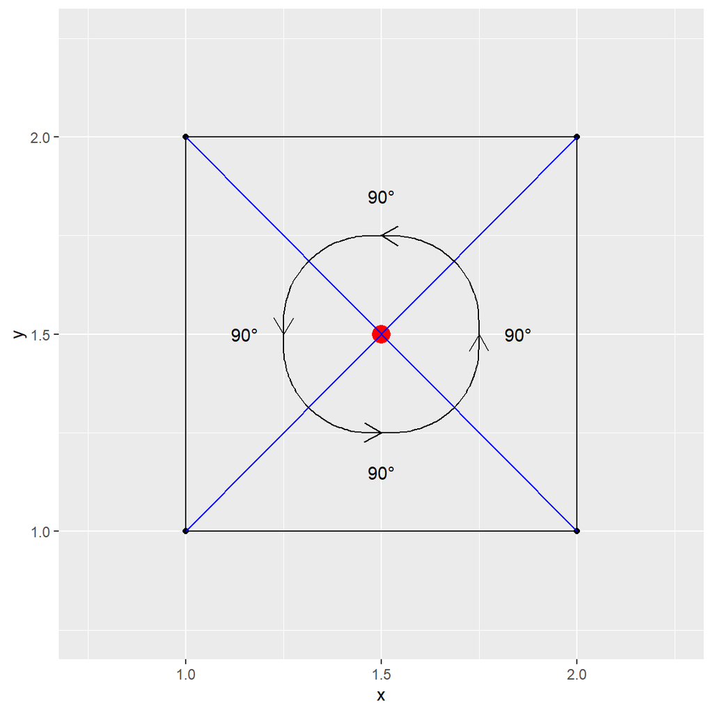

If your point is in the square, then the sum of of the angles formed should be 360° (or -360°). Now, instead of a square take any shape and apply this same principle. For every point, you will check if the sum of angles will be close to 360°. To be very confident, in this function, this sum of angle divided by 360 needs to be between 359.9995/360 and 1. This threshold is arbitrary but very tight which allow almost any mistakes.

If we continue with our example of our square :

```r
square <- data.frame(x = c(1,1,2,2), y = c(1,2,2,1))
point_in <- c(1.5,1.5)
point_out <- c(2.1,2)

is_in_zone(square, point_in)  #TRUE
is_in_zone(square, point_out) #FALSE

#You can create way more complicated border. You'll just need a data frame of 2 columns named x and y.
```

[More information](http://www.eecs.umich.edu/courses/eecs380/HANDOUTS/PROJ2/InsidePoly.html)

### Peptide analysis

IMPRINTS.CETSA .app also contains functions to analyse IMPRINTS-CETSA on the peptide level. Their names always start with ‘imprints’ and ends with ‘peptides’. One of the main goal is the search for potential cleaved peptides.

#### $\underline{1.\space Read\space your\space data}$

The first step is to read your peptide data. For that, you’ll need the PeptideGroup files from Proteome Discoverer and the function ‘imprints_read_peptides’. For easier handle, you can put all your peptide file in a folder named ‘Analysis_files’ for example.

```r
library(IMPRINTS.CETSA .app)

peptides <- imprints_read_peptides(peptides_files = list.files("Analysis_files",     # your files
                                                               pattern = "Peptide",
                                                               full.names = T),
                                   treatment = c("B1_Vehicle", "B1_DrugA", "B1_DrugB",  # the treatments corresponding to your channel
                                                 "B2_Vehicle","B2_DrugA", "B2_DrugB",
                                                 "B3_Vehicle", "B3_DrugA", "B3_DrugB",
                                                 "Mix"),
                                   temperatures = c("37C", "47C", "50C", "52C", "54C", "57C"), # temperatures from your corresponding files
                                   proteins = "Analysis_files/proteins_imprints_caldiff.txt") # The proteins from which you want to analyze the peptides, can be a dataframe
```

All peptides files are now joined and only the peptides from the proteins you analyzed are kept. A file is also saved.

#### $\underline{2.\space Normalize\space your\space data}$

Second step is now to normalize the peptides data the same way it is done for protein using the ‘imprints_normalization’ function from IMPRINTS.CETSA package.

```r
peptides_norm <- imprints_normalize_peptides(peptides)
```

It returns the normalize, non log2 transformed, peptide data. A file is also saved.

#### $\underline{3.\space Plot\space and\space check\space your\space data}$

You can now start to plot imprints of your peptides. It’s a lot of data, so it’s better to select some proteins first.

```r
# one of your hitlist
proteins <- hitlist$id
peptides_norm_diff <-  imprints_sequence_peptides(peptides_norm,
                                                  proteins =  proteins,
                                                  barplot = TRUE,
                                                  control = "Vehicle") # needs to specify control from your experiment
```

The function returns the caldiff output from all peptides from each protein you selected. It also save it as a file and plot the barplots from all these peptides.

#### $\underline{4.\space Searching\space for\space potentially\space cleaved\space proteins}$

From you IMPRINTS dataset on the peptide level, you can look for potential cleaved proteins; i.e. proteins with peptides with greater abundance and/or stabilization than others. For example, you can have peptides located between the N-terminal position and a cleavage site with greater fold-changes than the ones that are after the cleavage site and before the C-terminal. We call it RESP effect for REgional Stabilization Proteolysis. Using the function `imprints_cleaved_peptides`, you can compute p-values for each protein telling how likely a protein is to be cleaved based on the computed potential cleavage site. For that, let’s compute fold-changes from all peptides. For more details, check the documentation of the function `imprints_cleaved_peptides`.

```r
# no barplotting this time as it would be quite long
peptidesall_norm_diff <-  imprints_sequence_peptides(peptides_norm, control = "Vehicle",
                                                     barplot = FALSE)

potential_cleaved <- imprints_cleaved_peptides(peptides_norm, peptidesall_norm_diff,
                                               control = "Vehicle", FDR = 0.01)
```

This function returns a data frame that contains the proteins with RESP effect that passes the cutoffs and their respective potential cleaved sites. It also saves automatically the data frame as an excel file and a volcano plot from each treatment tested. By default, the function `imprints_cleaved_peptides` will categorize the obtained hits in 6 different category: RESP for REgional Stabilization after Proteolysis, SP for Single Peptide, MP for multiple peptides and FP for false positive. When a small ‘m’ is added to SP or MP it stands for modified, meaning that at least one of the peptides is modified. If you don’t want to perform this last step, you’ll need to set up the argument `categorize` to `FALSE`. But you can still perform categorization after using the function `imprints_categorize_peptides` like so:

```r
# compute potential cleaved hit list
potential_cleaved_notcat <- imprints_cleaved_peptides(peptides_norm, peptidesall_norm_diff,
                                                      control = "Vehicle", FDR = 0.01,
                                                      categorize = FALSE)

# perform categorization
potential_cleaved_cat <- imprints_categorize_peptides(peptides_norm, potential_cleaved_notcat,
                                                      control = "Vehicle")
```

The function `imprints_categorize_peptides` will save the results in an xlsx file. You can set its name using the parameter `xlsxname` or choose to not save the results by setting `save_xlsx` to `FALSE`.

#### $\underline{5.\space Plot\space and\space check\space the\space peptides\space of\space each\space categorized\space proteins\space}$

To illustrate the RESP effect, you can sum all the fold changes from all the peptides before the cleavage site and after, and this for all proteins found with significant RESP effect. Also, to better validate the results, it is good practice to also plot all the corresponding peptides alongside it.

To do so, you can use the function `imprints_barplotting_categorize_peptides`. It will plot each ‘RESP plot’ from each protein followed by all its corresponding peptides in one pdf, all ordered according their categories following this order: RESP, SP, SPm, MP, MPm and FP. If you don’t provide a categorized RESP summary, the function will call automatically `imprints_categorize_peptides` to do so but it will not save the resulting xlsx file.

```r
imprints_barplotting_categorize_peptides(peptides_norm, potential_cleaved_cat,
                                         treatment = "DrugB", control = "Vehicle",
                                         color = "red")
```

However, when a hit is returned by `imprints_cleaved_peptides`, it means that this protein has a peptide position where the IMPRINTS profiles of the two obtained parts are significantly different. This difference can be caused by protein modification and mainly proteolysis as discussed previously. But if a splicing form of a protein is more expressed than its canonical form, a significant difference in the profiles can also occur, i.e. the common part of the sequence between the canonical form and the isoform should shift the same way but not the different part. To refilter the hit list and give the possible splicing forms which could be more expressed based on the output of `imprints_cleaved_peptides` and the sequence alignments of the isoform sequence and its corresponding canonical form, you can use the function `imprints_isoform_peptides`.

```r
isoform_ambiguity <- imprints_isoform_peptides(peptides_norm, peptidesall_norm_diff,
                                               control = "Vehicle", fasta = "path/to/your/FASTA_file.fasta")
```

It will need the FASTA file you used for your search and it will then make a query to Uniprot to retrieve all isoforms of each of your proteins. Next, it will call BLAST to align the isoform sequences and their corresponding canonical form. From there, the function will returned the proteins that could be considered a hit by `imprints_cleaved_peptides` due to alternative splicing forms being more expressed. As for `imprints_categorize_peptides`, it will automatically save the results in an xlsx file.

If now you want to visualize the isoform sequence alignement with its canonical form and see how the aligned peptides shift to evaluate how likely it is that the RESP effect can be explained by an alternative splicing form, you can use the `imprints_plotting_isoform_peptides` like so:

```r
imprints_plotting_isoform_peptides(peptides_norm, isoform_ambiguity,
                                   control = "Vehicle", treatment = "DrugB",
                                   ret_plot = FALSE, save_pdf = TRUE)
```

This will save each plot in a pdf file.

#### $\underline{6.\space Multiple\space dataset\space analysis}$

If you’re satisfied with th results, you can continue and expand it to the second treatment, potentially only keeping hits categorized as ‘RESP’; here we will keep all. You can then compute the resulting datasets from the RESP analysis.

```r
## Drug A
# keeping only drug A
peptides_norm_drugA <- peptides_norm[,-grep("_DrugB$", colnames(peptides_norm))]
potential_cleaved_drugA <- potential_cleaved %>%
  dplyr::filter(treatment == "DrugA") %>%
  select(id, cleaved_site)
# computing fold-changes
peptides_cleaved_drugA <-  imprints_sequence_peptides(peptides_norm_drugA,
                                                      proteins =  potential_cleaved_drugA$id,
                                                      sequence = potential_cleaved_drugA$cleaved_site, # give sequence = the potential cleavage sites
                                                      control = "Vehicle") # needs to specify control from your experiment
# removing peptides considred as cleavage sites
peptides_cleaved_drugA <- imprints_remove_peptides(peptides_cleaved_drugA,
                                                   proteins =  potential_cleaved_drugA$protein,  # the protein from which you want to remove the specific sequence
                                                   sequence = potential_cleaved_drugA$cleaved_site) # the sequence you want to remove

## Drug B
peptides_norm_drugB <- peptides_norm[,-grep("_DrugA$", colnames(peptides_norm))]
potential_cleaved_drugB <- potential_cleaved %>%
  dplyr::filter(treatment == "DrugB") %>%
  select(id, cleaved_site)
# computing fold-changes
peptides_cleaved_drugB <-  imprints_sequence_peptides(peptides_norm_drugB,
                                                      proteins =  potential_cleaved_drugB$id,
                                                      sequence = potential_cleaved_drugB$cleaved_site, # give sequence = the potential cleavage sites
                                                      control = "Vehicle") # needs to specify control from your experiment
# removing peptides considred as cleavage sites
peptides_cleaved_drugB <- imprints_remove_peptides(peptides_cleaved_drugB,
                                                   proteins =  potential_cleaved_drugB$protein,  # the protein from which you want to remove the sepecific sequence
                                                   sequence = potential_cleaved_drugB$cleaved_site) # the sequence you want to remove
```

Then, you can join your datasets (can be more than 2). Usually, the exact same peptide sequence is not found between the datasets. Since the fold change are summed, we can join the closest sequences using the parameter `mode` set to `"partial"`.

```r
peptides_cleaved <- list(peptides_cleaved_drugA, peptides_cleaved_drugB) # you could add more datasets

peptides_cleaved <- imprints_join_peptides(peptides_cleaved, mode = "partial")
```

#### $\underline{7.\space Plot\space your\space results}$

You can use the `imprints_barplotting_peptides` function to plot your final results. Here we will plot in the RESP effect to directly compare the two IMPRINTS profiles from the two parts of the proteins obtained. For that you can set the parameter `format` to `RESP_peptide`. If you want just to plot each peptide, set it to `individual_peptide` or if you prefer to visualize all peptide per protein in one plot set it to `peptide_one`.

```r
# save the imprints in a pdf
imprints_barplotting_peptides(peptides_cleaved, format = "RESP_peptide",
                              save_pdf = T, ret_plot = F)
```

## Details

If you want more information, remember that you can use the operator ‘?’ and type the name of the function for accessing the documentation. You can also use the function ‘View()’ to see the source the code or see it on the [github](https://github.com/mgerault/IMPRINTS.CETSA.app) repository.

## Any questions or bug report ?

Feel free to send me an e-mail.